# Le nozze di Figaro

Commedia per musica in vier Akten (1786)

Musik von Wolfgang Amadeus Mozart  
Text von Lorenzo Da Ponte

[Tickets](https://staatsoper-berlin.eventim-inhouse.de/webshop/webticket/shop?language=de&production=999)

[figure not shown]

Unser Figaro macht Ferien: In einer Villa am Meer, in der Sommerfrische, kochen die Emotionen hoch, werden alte Rechnungen beglichen und Intrigen gesponnen. Am Ende dieses „tollen Tages“ jedoch steht das Verzeihen: Wieder einmal hat die Liebe gesiegt und lässt alle zufrieden zurück: Graf und Gräfin, Figaro und Susanna, Bartolo und Marcellina – und selbst Cherubino, der zuvor alles durcheinander gewirbelt hat.

Mozarts besonderes Interesse galt dem Musiktheater, der Opera seria wie der Opera buffa. Die Trilogie der „Da-Ponte-Opern“, in den mittleren und späten 1780er Jahren auf Libretti des italienischen Theaterdichters geschrieben, hat nicht umsonst Berühmtheit erlangt. Dabei ist der Figaro, schon zu Lebzeiten ein Erfolgsstück, zum Musterbeispiel einer "musikalischen Komödie" geworden, von Vielen bewundert, von Regisseuren, Dirigenten, Sängerinnen und Sängern und nicht zuletzt dem Publikum zu einem ihrer Favoriten erhoben. Kaum einem Komponisten ist es so wie Mozart gelungen, feine und feinste seelische Regungen seiner Figuren in der Musik offenbar werden zu lassen, ganz unmittelbar, hochgradig prägnant und eindrucksvoll. Jürgen Flimms Inszenierung erweckt Mozarts komödiantisches Meisterwerk zum Leben, indem sie den Figuren Raum gibt, im entspannten Ambiente, auf dem Lande nahe beim Meer, ihre Gefühlswelten zu eröffnen, ihre Wünsche und Neigungen zu artikulieren sowie Konflikte zu schärfen und wieder zu lösen.

Samstag, 8. Februar 2025  
19.00 Uhr

[Staatsoper Unter den Linden](https://www.staatsoper-berlin.de/de/ihr-besuch/anfahrt/staatsoper-unter-den-linden.35/)

[Tickets](https://staatsoper-berlin.eventim-inhouse.de/webshop/webticket/shop?language=de&event=18300)

Dauer: ca. 3:25 h inklusive einer Pause

Sprache: In italienischer Sprache mit deutschen und englischen Übertiteln

Altersempfehlung: ab 14 Jahren

## Besetzung

- Musikalische Leitung:

  [Finnegan Downie Dear](https://www.staatsoper-berlin.de/de/kuenstler/finnegan-downie-dear.2216/)
- Inszenierung:

  [Jürgen Flimm](https://www.staatsoper-berlin.de/de/kuenstler/juergen-flimm.1024/)
- Mitarbeit Regie:

  [Gudrun Hartmann](https://www.staatsoper-berlin.de/de/kuenstler/gudrun-hartmann.1025/)
- Szenische Einstudierung:

  [Marcin Łakomicki](https://www.staatsoper-berlin.de/de/kuenstler/marcin-lakomicki.1324/)
- Bühne:

  [Magdalena Gut](https://www.staatsoper-berlin.de/de/kuenstler/magdalena-gut.1026/)
- Kostüme:

  [Ursula Kudrna](https://www.staatsoper-berlin.de/de/kuenstler/ursula-kudrna.1027/)
- Choreographie:

  [Catharina Lühr](https://www.staatsoper-berlin.de/de/kuenstler/catharina-luehr.1346/)
- Licht:

  [Olaf Freese](https://www.staatsoper-berlin.de/de/kuenstler/olaf-freese.1013/)
- Graf Almaviva:

  [Gyula Orendt](https://www.staatsoper-berlin.de/de/kuenstler/gyula-orendt.1017/)
- Gräfin Almaviva:

  [Evelin Novak](https://www.staatsoper-berlin.de/de/kuenstler/evelin-novak.1107/)
- Susanna:

  [Maria Kokareva](https://www.staatsoper-berlin.de/de/kuenstler/maria-kokareva.3270/)
- Figaro:

  [Riccardo Fassi](https://www.staatsoper-berlin.de/de/kuenstler/riccardo-fassi.2733/)
- Cherubino:

  [Rebecka Wallroth](https://www.staatsoper-berlin.de/de/kuenstler/rebecka-wallroth.3275/)
- Marcellina:

  [Natalia Skrycka](https://www.staatsoper-berlin.de/de/kuenstler/natalia-skrycka.1049/)
- Basilio:

  [Florian Hoffmann](https://www.staatsoper-berlin.de/de/kuenstler/florian-hoffmann.1034/)
- Don Curzio:

  [Marcel Beekman](https://www.staatsoper-berlin.de/de/kuenstler/marcel-beekman.3500/)
- Bartolo:

  [Patrick Zielke](https://www.staatsoper-berlin.de/de/kuenstler/patrick-zielke.3501/)
- Antonio:

  [Olaf Bär](https://www.staatsoper-berlin.de/de/kuenstler/olaf-baer.1037/)
- Barbarina:

## Medien

[figure not shown]

[figure not shown]

[figure not shown]

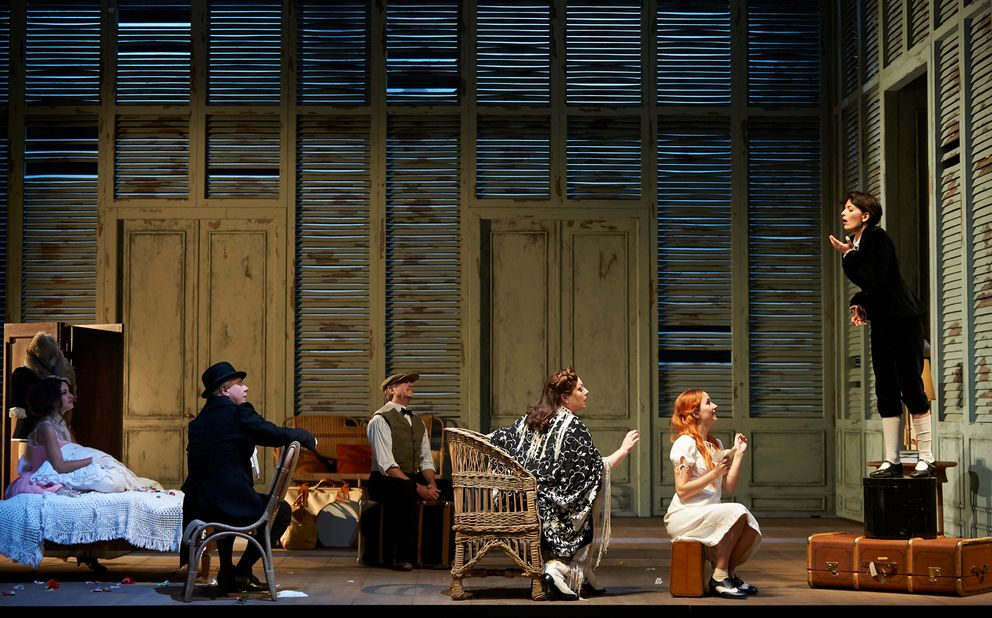

[Programmbuch Download](https://www.staatsoper-berlin.de/downloads-b/de/produktion/7/programmbuch/0c3bdba7fadc97fe775c337a05d47e51/SOB_LeNozzeDiFigaro_Programmheft_Web.pdf)

[figure not shown]